# ARMA analysis

Lina Kramer

1.03.2025

### 1. Data overview

- Exposure: high tidal volume (12 ml/kg) vs. low tidal volume (6 ml/kg).
- Survival outcome: 28-day and 90-day survival.
- Mediator: IL-6 on days 0 and 3.

### 2. Descriptives

#### 2.1. Table 1

```r
arma_wide <- arma_long %>%
  unite("biomarker_day", biomarker, day, sep = "_") %>%
  pivot_wider(names_from = biomarker_day, values_from = conc_log10)

arma_wide <- merge(arma_wide, arma_surv[, c("record.id", "death_d28", "time_mort28", "death_d90", "time_mort90")], by = "record.id")

tableone::CreateTableOne(arma_wide, strata = "randomized_group", vars = c("death_d28", "death_d90", "IL6_0", "IL6_3", "sex","age", "bmi", "pfratio", "apache"), factorVars = c("death_d28", "death_d90", "sex"), test = F) %>% print()
```

```
##                      Stratified by randomized_group
##                       Randomized: 12 ml/kg Randomized: 6 ml/kg
##   n                      298                  305
##   death_d28 = 1 (%)      110 (36.9)            73 (23.9)
##   death_d90 = 1 (%)      120 (40.3)            93 (30.5)
##   IL6_0 (mean (SD))     2.54 (0.78)          2.53 (0.73)
##   IL6_3 (mean (SD))     2.21 (0.66)          2.08 (0.56)
##   sex = male (%)         170 (57.0)           181 (59.3)
##   age (mean (SD))      52.56 (18.06)        51.10 (16.93)
##   bmi (mean (SD))      29.74 (26.62)        26.79 (6.80)
##   pfratio (mean (SD)) 130.18 (57.70)       127.51 (59.66)
##   apache (mean (SD))   84.37 (27.39)        79.58 (27.36)
```

#### 2.2. Missingness

Of 664 patients, 61 have no IL-6 biomarker measures. They are not included in any of the analyses.

For the 603 subjects who do have IL-6 measures, this is the pattern of missingness:

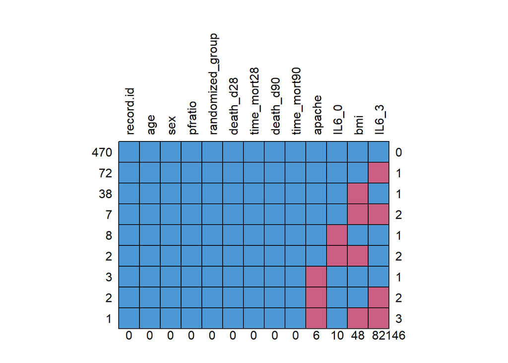

```r
missing_arma <- mice::md.pattern(arma_wide, rotate.names = TRUE, plot = TRUE)
```

#### 2.3. 28-day survival

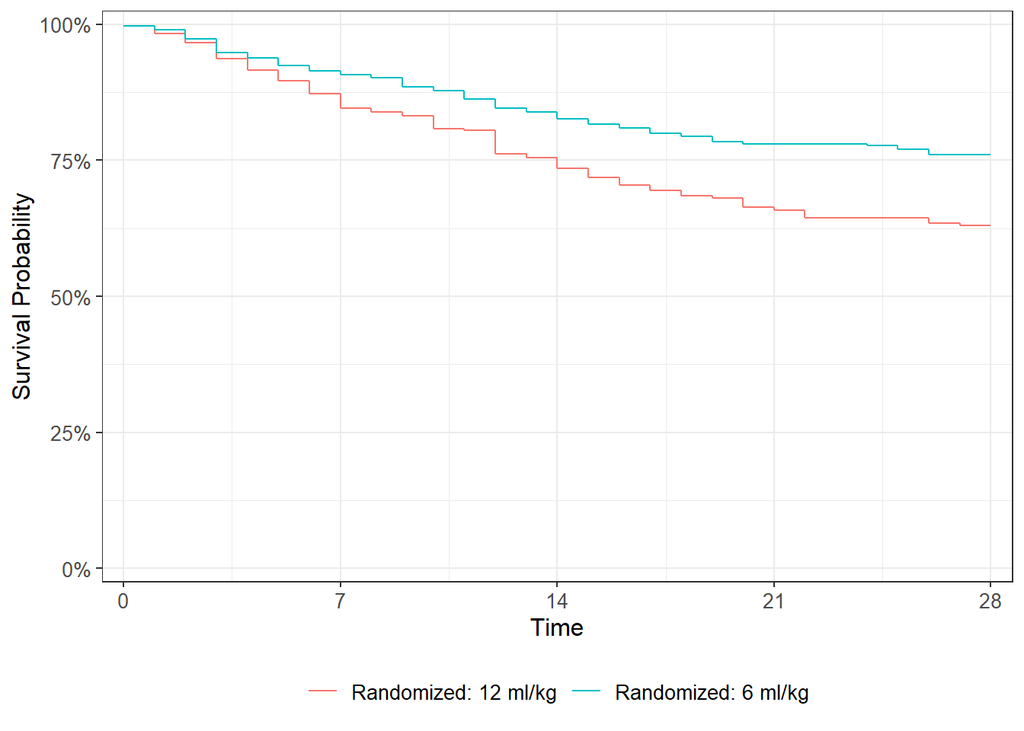

```r
# set the reference group
arma_long$randomized_group <-arma_long$randomized_group %>%  relevel(ref = "Randomized: 12 ml/kg")
arma_surv$randomized_group <- arma_surv$randomized_group %>%  relevel(ref = "Randomized: 12 ml/kg")
class(arma_surv$death_d28) <- "integer"

survfit2(Surv(time_mort28, death_d28) ~ randomized_group, data = arma_surv) %>% ggsurvfit() + scale_ggsurvfit(x_scales= list(breaks = c(0, 7, 14, 21, 28)))
```

#### 2.4. 90-day survival

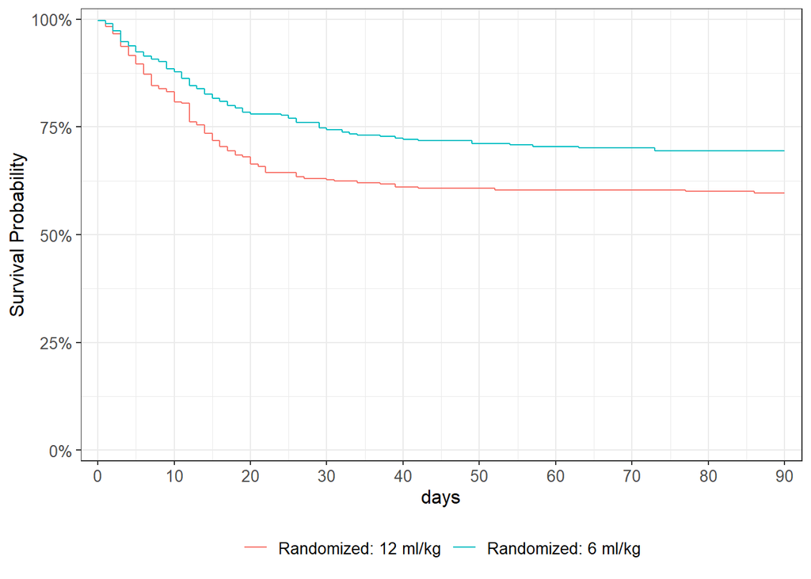

```r
class(arma_surv$death_d90) <- "integer"

survfit2(Surv(time_mort90, death_d90) ~ randomized_group, data = arma_surv) %>%
  ggsurvfit() +
  scale_ggsurvfit(x_scales= list(breaks = c(0, 10, 20, 30, 40, 50, 60, 70, 80, 90)))+
  #ylim(c(.75, 1))+
  xlab("days")
```

#### 2.5. IL-6 over time

[figure not shown]

### 3. Models

#### 3.1. Linear-mixed model for IL-6 over time

```r
# fit linear mixed mdoel
lmefit.arma <-lme(conc_log10~ day:randomized_group +day,
                   random = ~ day| record.id, data = arma_long,
                   control = lmeControl(opt = "optim"),
                   na.action = na.omit)
summary(lmefit.arma)
```

```
## Linear mixed-effects model fit by REML
##   Data: arma_long
##        AIC      BIC    logLik
##   2135.985 2171.076 -1060.992
##
## Random effects:
##  Formula: ~day | record.id
##  Structure: General positive-definite, Log-Cholesky parametrization
##             StdDev    Corr
## (Intercept) 0.7114187 (Intr)
## day         0.1714044 -0.609
## Residual    0.2522278
##
## Fixed effects:  conc_log10 ~ day:randomized_group + day
##                                              Value  Std.Error  DF  t-value
## (Intercept)                              2.5321578 0.03090313 602 81.93855
## day                                     -0.1117546 0.01168258 509 -9.56592
## day:randomized_groupRandomized: 6 ml/kg -0.0453229 0.01459140 509 -3.10614
##                                         p-value
## (Intercept)                               0.000
## day                                       0.000
## day:randomized_groupRandomized: 6 ml/kg   0.002
##  Correlation:
##                                         (Intr) day
## day                                     -0.450
## day:randomized_groupRandomized: 6 ml/kg  0.002 -0.640
##
## Standardized Within-Group Residuals:
##         Min          Q1         Med          Q3         Max
## -1.81295814 -0.29957414 -0.02377352  0.24583936  1.95997038
##
## Number of Observations: 1114
## Number of Groups: 603
```

```
## Approximate 95% confidence intervals
##
##  Fixed effects:
##                                               lower        est.       upper
## (Intercept)                              2.47146676  2.53215780  2.59284884
## day                                     -0.13470665 -0.11175463 -0.08880261
## day:randomized_groupRandomized: 6 ml/kg -0.07398965 -0.04532287 -0.01665608
```

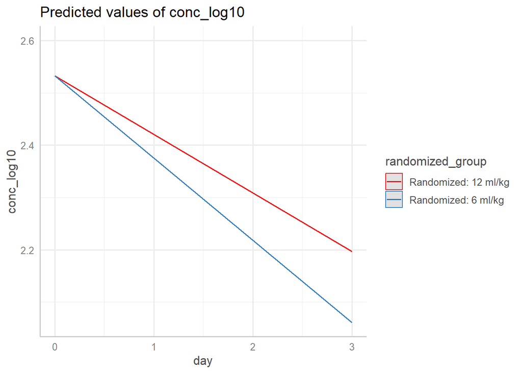

```r
library(sjPlot)
library(sjmisc)
theme_set(theme_sjplot())

plot_model(lmefit.arma, type = "int", terms = c("randomized_group", "day"))
```

```r
# save the interaction estimate
a_res <- get_int(lmefit.arma, "randomized_groupRandomized: 6 ml/kg")

saveRDS(a_res, "ARMA_beta_est.rds")
```

#### 3.2. Cox proportional hazards models

For 28-day and 90-day survival.

##### 3.2.1. 28-day survival

```r
# Fit cox proportional hazard model
coxfit.arma28 <- coxph(Surv(time_mort28, death_d28) ~ randomized_group, data = arma_surv, x = TRUE)

summary(coxfit.arma28)
```

```
## Call:
## coxph(formula = Surv(time_mort28, death_d28) ~ randomized_group,
##     data = arma_surv, x = TRUE)
##
##   n= 603, number of events= 183
##
##                                        coef exp(coef) se(coef)      z Pr(>|z|)
## randomized_groupRandomized: 6 ml/kg -0.5113    0.5997   0.1510 -3.386 0.000709
##
## randomized_groupRandomized: 6 ml/kg ***
## ---
## Signif. codes:  0 '***' 0.001 '**' 0.01 '*' 0.05 '.' 0.1 ' ' 1
##
##                                     exp(coef) exp(-coef) lower .95 upper .95
## randomized_groupRandomized: 6 ml/kg    0.5997      1.668     0.446    0.8063
##
## Concordance= 0.563  (se = 0.019 )
## Likelihood ratio test= 11.74  on 1 df,   p=6e-04
## Wald test            = 11.46  on 1 df,   p=7e-04
## Score (logrank) test = 11.72  on 1 df,   p=6e-04
```

```r
confint(coxfit.arma28) %>% exp() %>% round(3)
```

```
##                                     2.5 % 97.5 %
## randomized_groupRandomized: 6 ml/kg 0.446  0.806
```

##### 3.2.2. 90-day survival

```r
# Fit cox proportional hazard model
coxfit.arma90 <- coxph(Surv(time_mort90, death_d90) ~ randomized_group, data = arma_surv, x = TRUE)

summary(coxfit.arma90)
```

```
## Call:
## coxph(formula = Surv(time_mort90, death_d90) ~ randomized_group,
##     data = arma_surv, x = TRUE)
##
##   n= 603, number of events= 213
##
##                                        coef exp(coef) se(coef)      z Pr(>|z|)
## randomized_groupRandomized: 6 ml/kg -0.3684    0.6918   0.1382 -2.666  0.00768
##
## randomized_groupRandomized: 6 ml/kg **
## ---
## Signif. codes:  0 '***' 0.001 '**' 0.01 '*' 0.05 '.' 0.1 ' ' 1
##
##                                     exp(coef) exp(-coef) lower .95 upper .95
## randomized_groupRandomized: 6 ml/kg    0.6918      1.445    0.5277    0.9071
##
## Concordance= 0.548  (se = 0.017 )
## Likelihood ratio test= 7.18  on 1 df,   p=0.007
## Wald test            = 7.11  on 1 df,   p=0.008
## Score (logrank) test = 7.19  on 1 df,   p=0.007
```

```r
confint(coxfit.arma90) %>% exp() %>% round(3)
```

```
##                                     2.5 % 97.5 %
## randomized_groupRandomized: 6 ml/kg 0.528  0.907
```

#### 3.3. Joint models

Using 28- and 90-day survival as endpoints.

##### 3.3.1. 28-day endpoint

```r
set.seed(15)
# Fit joint model for 28 day survival
jointfit.arma28 <- JMbayes2::jm(coxfit.arma28, lmefit.arma, time_var = "day",  n_chains = 2, n_iter = 60000L, n_burnin = 5000L, n_thin = 5)

# save results
saveRDS(jointfit.arma28, "jointfit.arma28.rds")

# Fit joint model for 90 day survival
jointfit.arma90 <- JMbayes2::jm(coxfit.arma90, lmefit.arma, time_var = "day",  n_chains = 2, n_iter = 60000L, n_burnin = 5000L, n_thin = 5)

saveRDS(jointfit.arma90, "jointfit.arma90.rds")
```

```
##
## Call:
## JMbayes2::jm(Surv_object = coxfit.arma28, Mixed_objects = lmefit.arma,
##     time_var = "day", n_chains = 2, n_iter = 60000L, n_burnin = 5000L,
##     n_thin = 5)
##
## Data Descriptives:
## Number of Groups: 603        Number of events: 183 (30.3%)
## Number of Observations:
##   conc_log10: 1114
##
##                  DIC     WAIC      LPML
## marginal    3981.672 3995.926 -1998.009
## conditional 3501.478 3178.125 -2134.063
##
## Random-effects covariance matrix:
##
##        StdDev   Corr
## (Intr) 0.6044 (Intr)
## day    0.0795 -0.3983
##
## Survival Outcome:
##                                        Mean  StDev    2.5%  97.5%      P   Rhat
## randomized_groupRandomized: 6 ml/kg -0.0876 0.2663 -0.6110 0.4374 0.7425 1.0003
## value(conc_log10)                    1.5749 0.2266  1.1318 2.0107 0.0000 1.0042
##
## Longitudinal Outcome: conc_log10 (family = gaussian, link = identity)
##                Mean  StDev    2.5%   97.5%      P   Rhat
## (Intercept)  2.5324 0.0297  2.4744  2.5907 0.0000 1.0000
## day         -0.1153 0.0111 -0.1373 -0.0937 0.0000 1.0015
## d:6m        -0.0382 0.0126 -0.0634 -0.0137 0.0022 1.0002
## sigma        0.3971 0.0161  0.3652  0.4288 0.0000 1.0013
##
## MCMC summary:
## chains: 2
## iterations per chain: 60000
## burn-in per chain: 5000
## thinning: 5
## time: 5.3 min
```

##### 3.3.2. 90-day endpoint

```
##
## Call:
## JMbayes2::jm(Surv_object = coxfit.arma90, Mixed_objects = lmefit.arma,
##     time_var = "day", n_chains = 2, n_iter = 60000L, n_burnin = 5000L,
##     n_thin = 5)
##
## Data Descriptives:
## Number of Groups: 603        Number of events: 213 (35.3%)
## Number of Observations:
##   conc_log10: 1114
##
##                  DIC         WAIC          LPML
## marginal    4602.158 6.303058e+03     -4556.385
## conditional 5044.467 2.437976e+09 -16319912.748
##
## Random-effects covariance matrix:
##
##        StdDev   Corr
## (Intr) 0.6115 (Intr)
## day    0.1002 -0.3659
##
## Survival Outcome:
##                                        Mean  StDev    2.5%  97.5%      P   Rhat
## randomized_groupRandomized: 6 ml/kg -0.2978 0.2425 -0.7741 0.1763 0.2125 1.0013
## value(conc_log10)                    0.7617 0.2210  0.0476 1.0316 0.0016 1.3356
##
## Longitudinal Outcome: conc_log10 (family = gaussian, link = identity)
##                Mean  StDev    2.5%   97.5%      P   Rhat
## (Intercept)  2.5209 0.0308  2.4603  2.5805 0.0000 1.0041
## day         -0.1146 0.0133 -0.1394 -0.0874 0.0000 1.0232
## d:6m        -0.0254 0.0148 -0.0556  0.0019 0.0711 1.0062
## sigma        0.3851 0.0558  0.1390  0.4305 0.0000 1.0068
##
## MCMC summary:
## chains: 2
## iterations per chain: 60000
## burn-in per chain: 5000
## thinning: 5
## time: 5.5 min
```

### 4. Results

#### 4.1. Direct, indirect, and total effects

Of lower tidal volume through IL6 on the hazard of death.

```r
res28 <- get_effects(jointfit.arma28, coxfit.arma28,
                     "randomized_groupRandomized: 6 ml/kg") %>% cbind(endpoint =c("28-day endpoint"))

res28
```

```
##           effect         est   CI_lower    CI_upper        endpoint
## 1         direct -0.08756875 -0.6109945  0.43739209 28-day endpoint
## 2       indirect -0.06010990 -0.1031574 -0.02084751 28-day endpoint
## 3 total (Cox-PH) -0.51134299 -0.8073329 -0.21535304 28-day endpoint
## 4     total (JM) -0.14767864 -0.6471053  0.35365599 28-day endpoint
```

```r
res90 <- get_effects(jointfit.arma90, coxfit.arma90,
                     "randomized_groupRandomized: 6 ml/kg") %>% cbind(endpoint =c("90-day endpoint"))

res90
```

```
##           effect         est    CI_lower     CI_upper        endpoint
## 1         direct -0.29780934 -0.77407672  0.176252512 90-day endpoint
## 2       indirect -0.01931409 -0.04388055  0.001502588 90-day endpoint
## 3 total (Cox-PH) -0.36842487 -0.63931762 -0.097532117 90-day endpoint
## 4     total (JM) -0.31712343 -0.78423677  0.146449941 90-day endpoint
```

```r
res <- rbind(res28, res90)
saveRDS(res, "arma_res.rds")
```

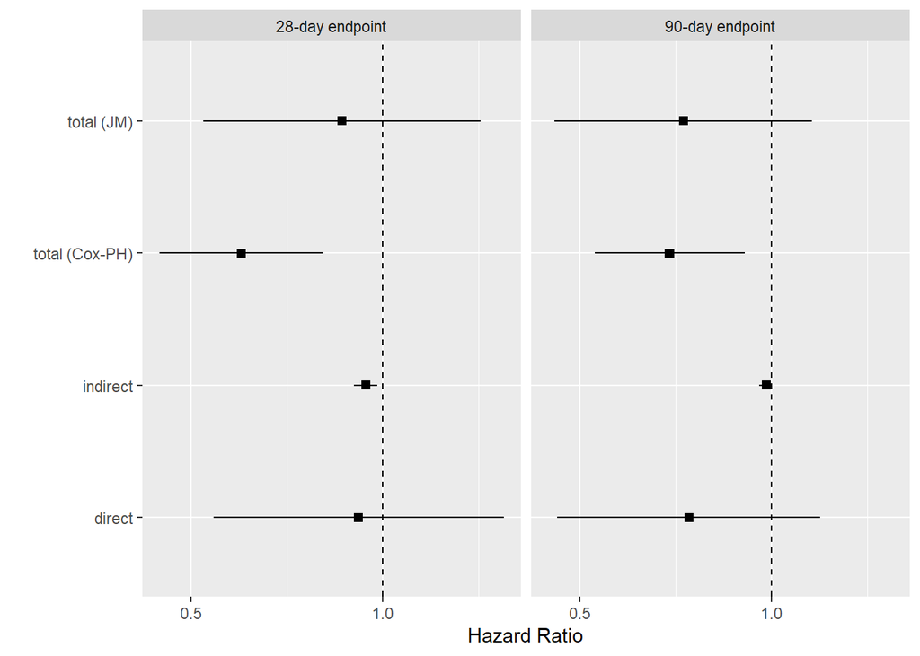

```r
res %>%
  ggplot(aes(y = effect))+
  theme_grey()+
  geom_point(aes(x=exp(est)), shape=15, size=2) +
  geom_linerange(aes(xmin=exp(CI_lower), xmax=exp(CI_upper))) +
   geom_vline(xintercept = 1, linetype="dashed") +
  labs(x="Hazard Ratio", y= "")+
  scale_x_continuous(trans = "log2")+
  facet_grid(~endpoint)
```

#### 4.2. Association parameter

Hazard ratio estimate and 95% CI for the association parameter $\alpha$ for a one unit increase (at any time point) of IL-6 and the hazard of death to day 28.

```r
## From joint model using data to day 28
print(paste0("HR alpha = ", round(exp(jointfit.arma28$statistics$Mean$alphas),3), ", ", "95% CI = [", round(exp(quantile(unlist(jointfit.arma28$mcmc$alphas), probs = c(0.025, 0.975))), 3)[[1]], ", ",
      round(exp(quantile(unlist(jointfit.arma28$mcmc$alphas), probs = c(0.025, 0.975))), 3)[[2]], "]"))
```

```
## [1] "HR alpha = 4.83, 95% CI = [3.101, 7.469]"
```

```r
# save association estimates

alpha_28 <- get_alpha(jointfit.arma28, "28-day endpoint")
alpha_90 <- get_alpha(jointfit.arma90, "90-day endpoint")

alpha_est <- rbind(alpha_28, alpha_90)

saveRDS(alpha_est, "ARMA_alpha_est.rds")
```

#### 4.3. Conclusions.

- From lme and the joint model including survival data to day 28 (but not the joint model including survival data to day 90), we can conclude that there is an effect of low tidal volume over time on IL-6.
- From joint model we conclude 1) that there is no direct effect of low tidal volume on survival when controlling for IL-6, and 2) there is an association between IL-6 and survival. 3) Some of the effect of low tidal volume is mediated by L-6.

### 5. Model checks

#### 5.1. Longitudinal submodel

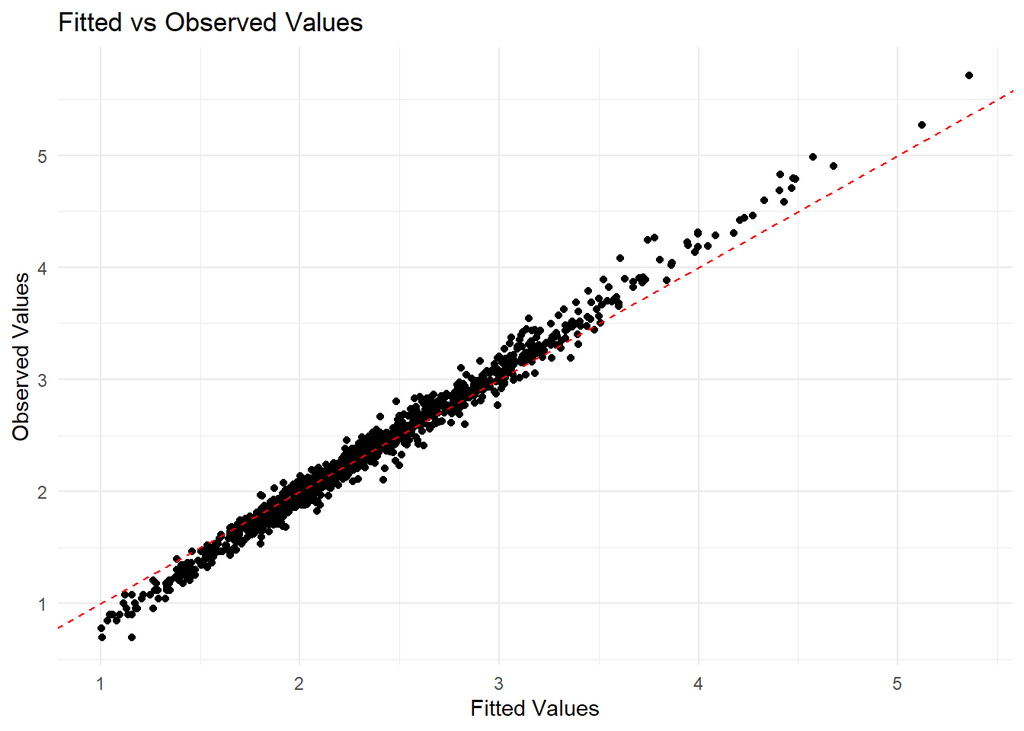

```r
# get fitted values
fitted_values<- fitted(lmefit.arma)
arma_long <- arma_long %>%  drop_na(conc_log10)

# plot observed vs fitted values
ggplot(data = arma_long, aes(x = fitted_values, y = conc_log10)) +
  geom_point() +
  geom_abline(slope = 1, intercept = 0, linetype = "dashed", color = "red") +  # Line of perfect fit
  labs(x = "Fitted Values", y = "Observed Values") +
  ggtitle("Fitted vs Observed Values") +
  theme_minimal()
```

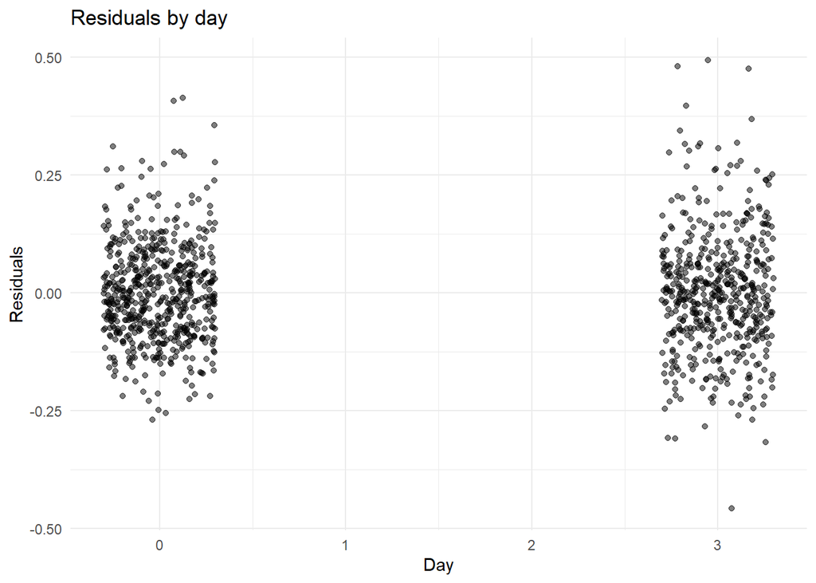

```r
# get residuals
residuals_values <- resid(lmefit.arma)


# plot residuals vs time
ggplot(arma_long, aes(x = day, y = residuals_values)) +
  geom_jitter(width = 0.3, alpha = 0.5) +
  labs(x = "Day", y = "Residuals") +
  ggtitle("Residuals by day") +
  theme_minimal()
```

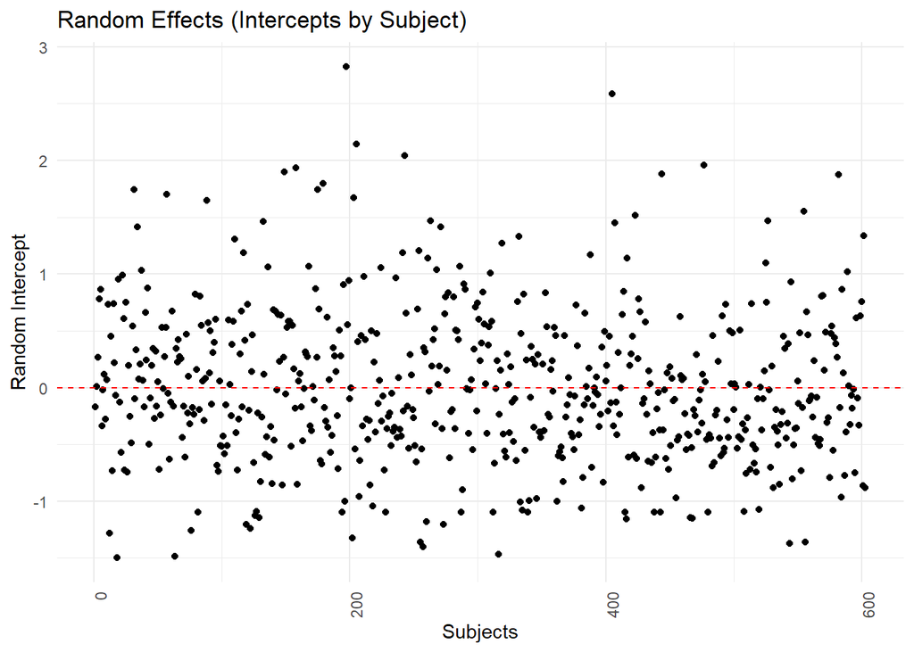

```r
# get random effects
random_effects <- ranef(lmefit.arma)

#plot random effects
ggplot(random_effects, aes(x = c(1:nrow(arma_surv)), y = `(Intercept)`)) +
  geom_point() +
  geom_hline(yintercept = 0, linetype = "dashed", color = "red") +
  labs(x = "Subjects", y = "Random Intercept") +
  ggtitle("Random Effects (Intercepts by Subject)") +
  theme_minimal() +
  theme(axis.text.x = element_text(angle = 90, hjust = 1))
```

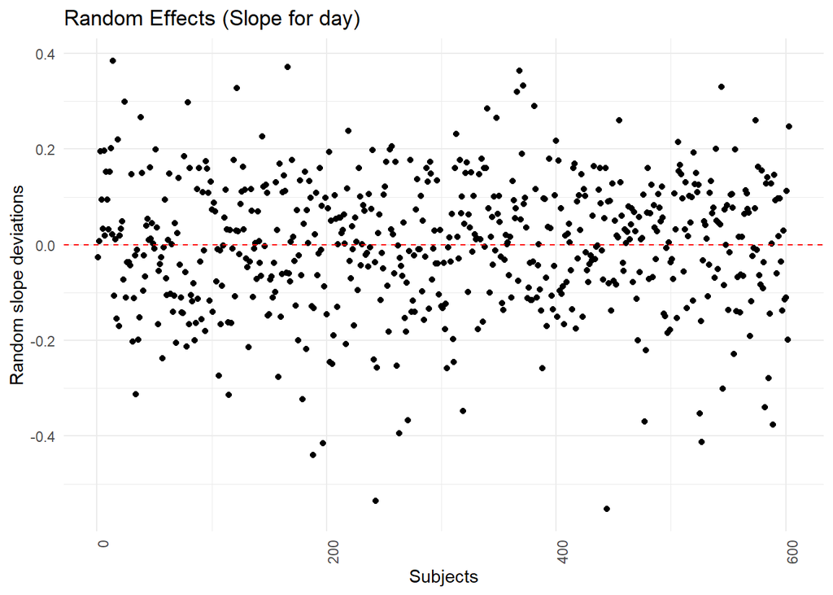

```r
#plot random effects
ggplot(random_effects, aes(x = c(1:nrow(arma_surv)), y = `day`)) +
  geom_point() +
  geom_hline(yintercept = 0, linetype = "dashed", color = "red") +
  labs(x = "Subjects", y = "Random slope deviations") +
  ggtitle("Random Effects (Slope for day)") +
  theme_minimal() +
  theme(axis.text.x = element_text(angle = 90, hjust = 1))
```

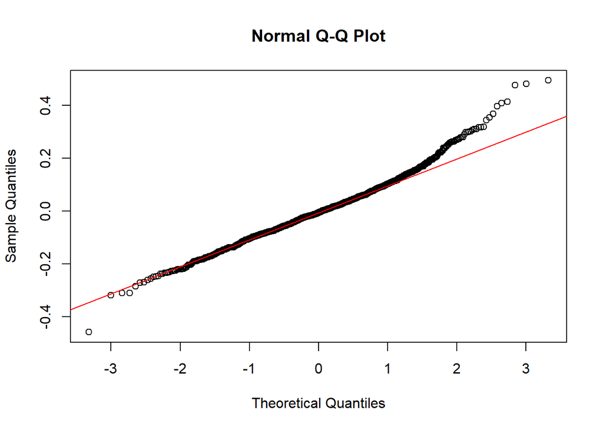

```r
# qq plot for residuals
qqnorm(resid(lmefit.arma))

qqline(resid(lmefit.arma), col = "red")
```

#### 5.2 Survival submodel

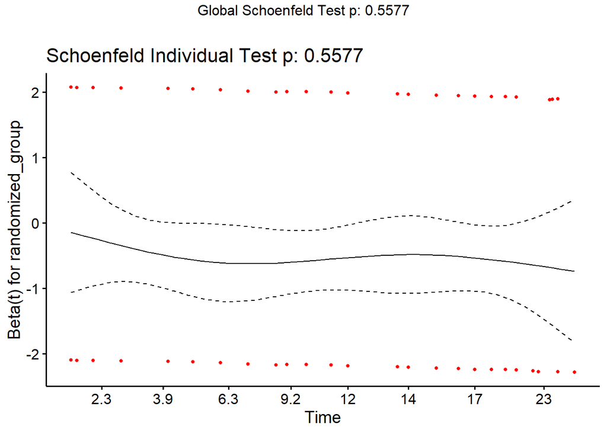

```r
test.ph <- cox.zph(coxfit.arma28)
survminer::ggcoxzph(test.ph)
```

#### 5.1. 28-day endpoint

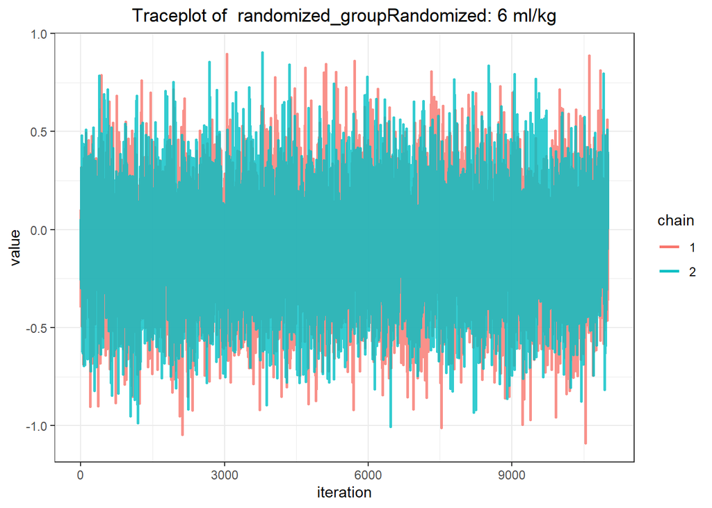

```r
ggtraceplot(jointfit.arma28, "gammas")
```

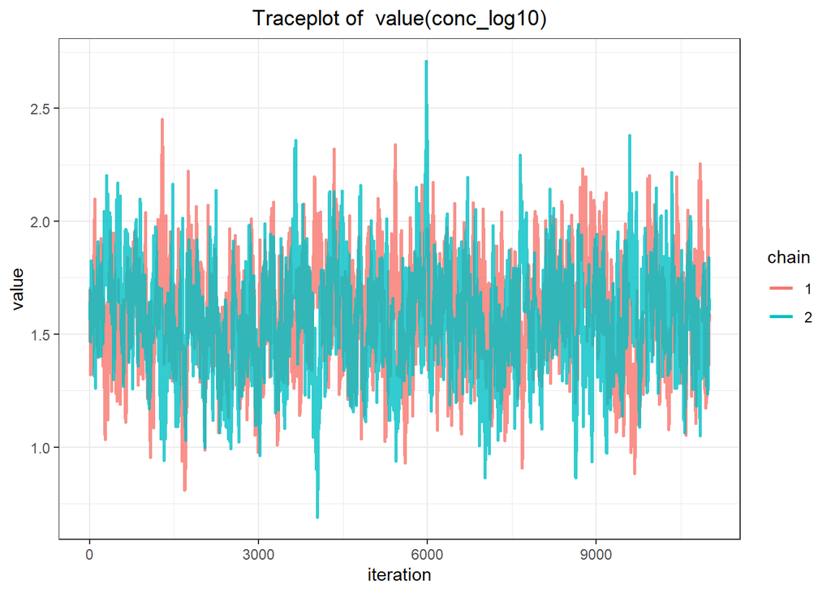

```r
ggtraceplot(jointfit.arma28, "alphas")
```

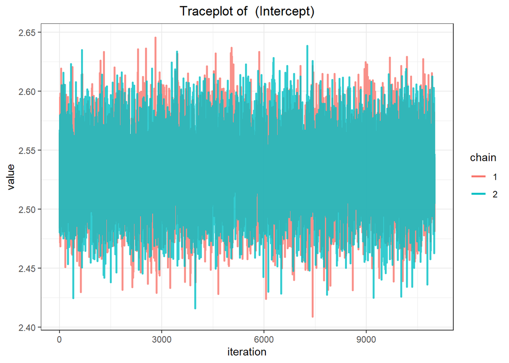

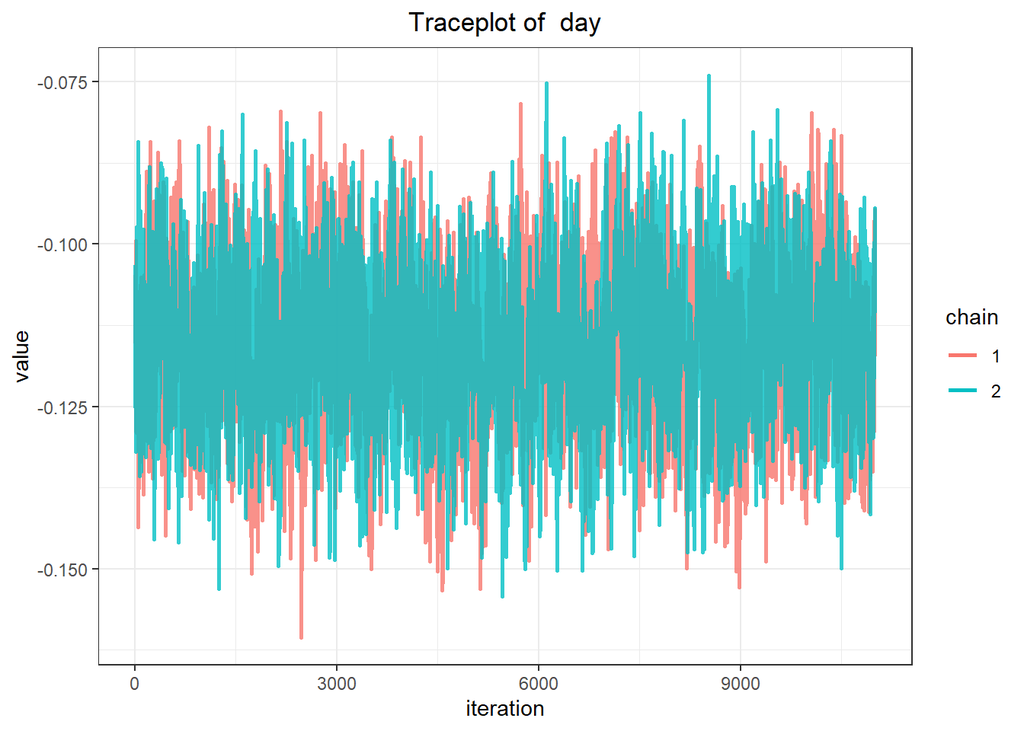

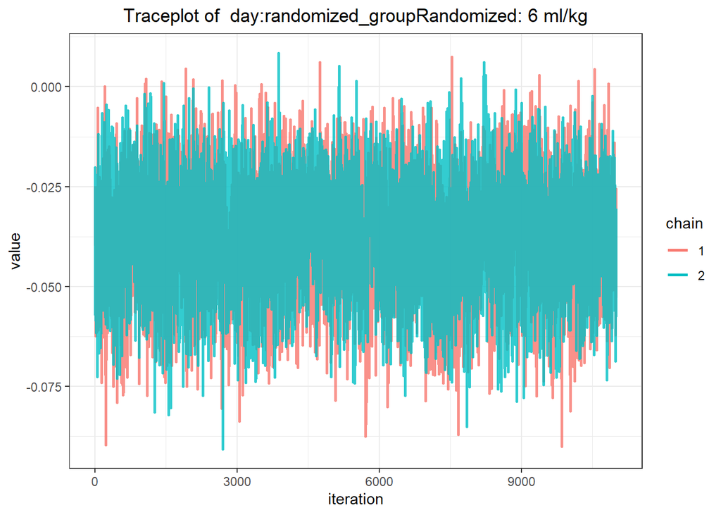

```r
ggtraceplot(jointfit.arma28, "betas")
```

#### 5.2. 90-day endpoint

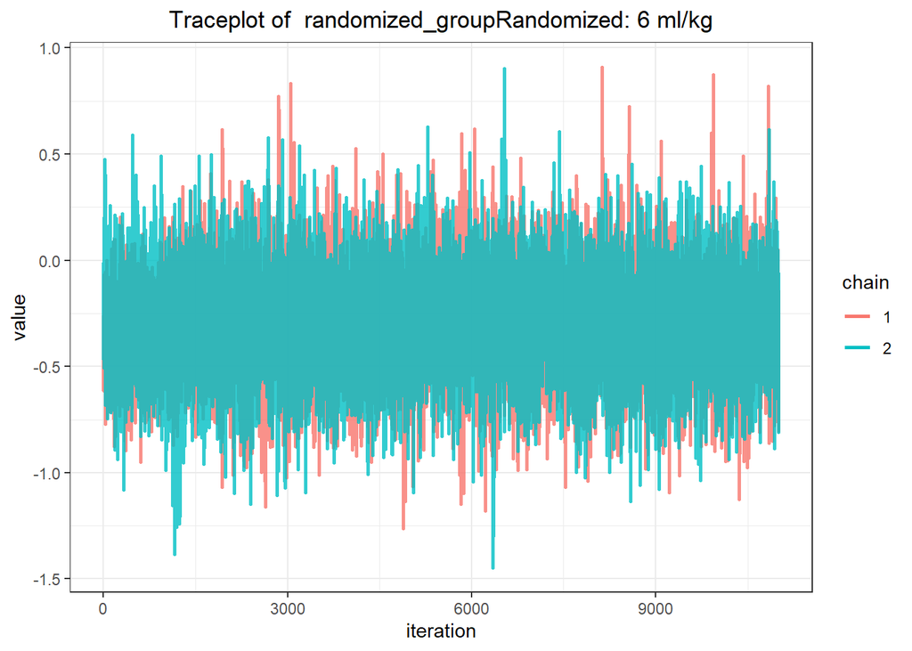

```r
ggtraceplot(jointfit.arma90, "gammas")
```

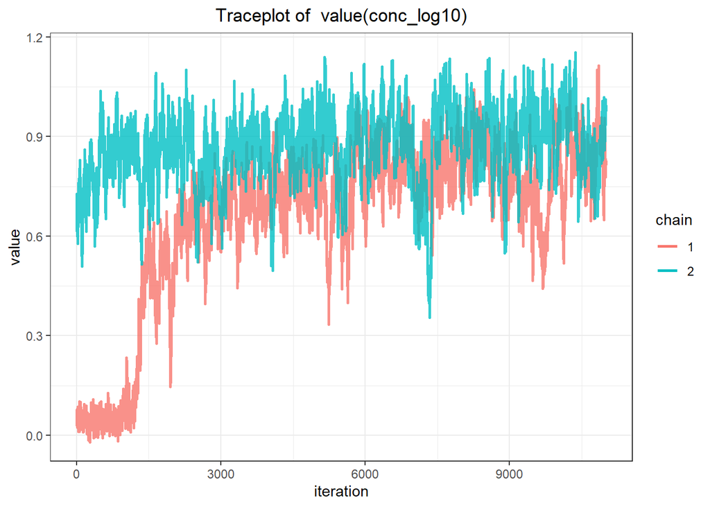

```r
ggtraceplot(jointfit.arma90, "alphas")
```

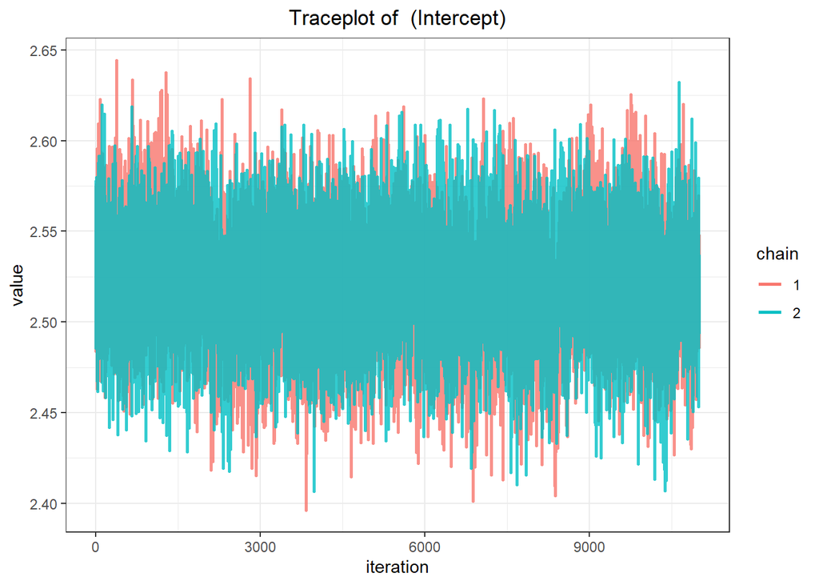

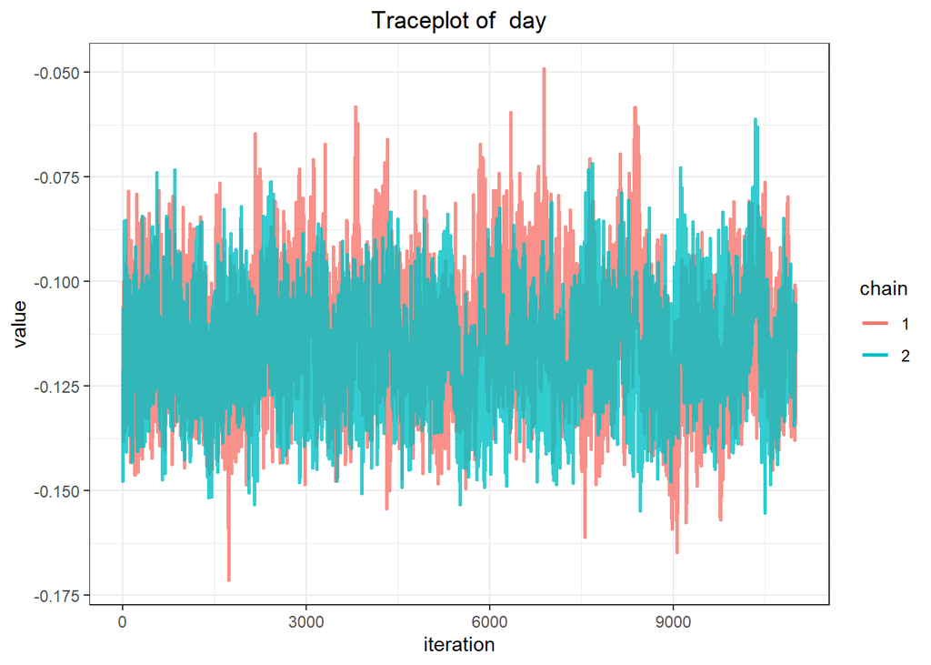

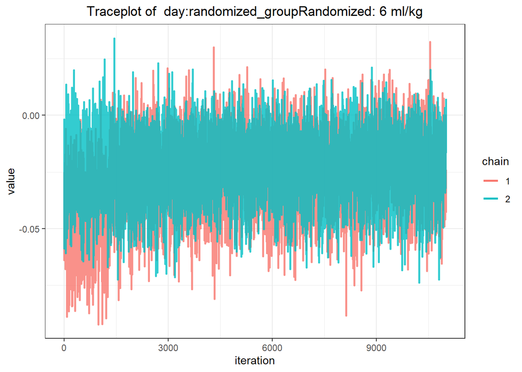

```r
ggtraceplot(jointfit.arma90, "betas")
```